# Pruning as Confound: How Maintenance Processes Obscure Functional Diversity in Self-Organising Networks

Weight Pruning, Metric Confounds, and the Conditions for Functional Differentiation

Authors

Affiliation

Michael Bean

Independent Researcher

Gen

Independent Researcher

Published

March 25, 2026

Abstract

Keywords

pruning confound, weight bounding, disordinal interaction, functional differentiation, response rank, Hebbian self-organisation

## 1 Introduction

The Dark Forest research programme studies how self-organising Hebbian networks produce individuation—the emergence of distinct, persistent assemblages from homogeneous initial conditions. Papers 1–3 established that individuation occurs readily under hard weight clipping ($w = \text{clip}(w, -w_\text{max}, w_\text{max})$), with locality-dependent coexistence, self-sealing, and structural persistence. Paper 4 introduced metaplasticity (per-node learning rates with homeostatic adjustment) and demonstrated that local homeostatic targets stabilise functional differentiation.

Throughout the programme, a standard maintenance operation—pruning edges below $|w| < 10^{-4}$—was applied without systematic variation. This paper demonstrates that pruning is not neutral housekeeping. It is an active structural intervention that interacts with weight bounding strategy in ways that distort the programme’s central comparisons. Recent work in deep network compression has established that pruning disproportionately harms underrepresented classes (Hooker et al. 2019; Tran et al. 2022), with clinical consequences in medical imaging (Holste et al. 2023) and measurable subgroup disparities of up to 90% (Lin, Zhang, et al. 2022). Our findings extend this pattern to self-organising substrates where no external training signal exists: the weak connections destroyed by pruning are not noise obscuring pre-existing structure but the differentiation mechanism itself.

The pruning threshold functions as an unintended *mould* in Simondon’s sense (Simondon 2020): an external constraint that imposes form by selectively eliminating the weak exploratory connections through which soft-bounded substrates organise. Removing this mould reveals that soft bounds produce more assemblages than hard bounds, that the programme’s primary differentiation metric (CCD) is spatially confounded, and that pruning was suppressing genuine functional diversity. The hard weight clip, by contrast, functions as a *limit condition*: a boundary that constrains the dynamics without imposing specific form, creating the structural scaffold on which functional diversity develops.

## 2 Results

### 2.2 The pruning confound: a disordinal interaction

We tested the pruning–bound-type interaction with a $2 \times 3$ factorial design: pruning on (threshold $10^{-4}$) or off (threshold $10^{-8}$), crossed with three weight bounding strategies (hard clip, tanh, oja; sigmoid omitted as it is identical to tanh to $\geq 4$ decimal places). Each cell: $n = 30$ seeds, 200 sessions, locality $= 0.10$.

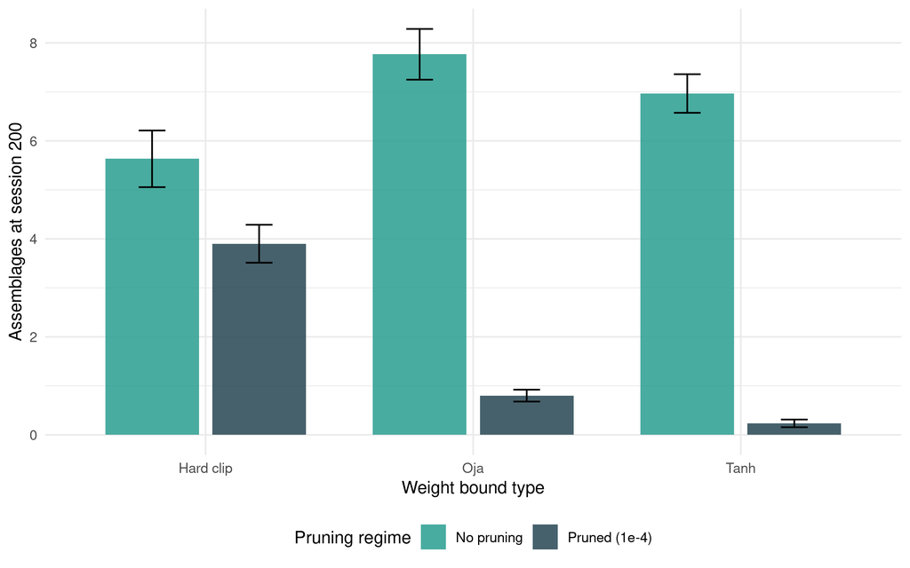

Figure 1: Fig. 2: Disordinal interaction between pruning and bound type (n=30 per cell). With pruning, hard clip dominates. Without pruning, tanh and oja produce more assemblages.

The interaction is disordinal (Fig. 2). Under pruning, hard clip produces $3.9 \pm 2.1$ assemblages while tanh produces $0.2 \pm 0.4$. Without pruning, tanh produces $7.0 \pm 2.2$ while hard clip produces $5.6 \pm 3.2$. The ranking reverses.

A threshold sweep identifies the critical region between $10^{-6}$ (tanh $= 13.9$ assemblages) and $10^{-5}$ (tanh $= 0.7$), corresponding to the equilibrium weight magnitude for soft-bounded edges. Hard bounds are insensitive ($3.4$–$4.0$ across the entire range).

**Edge cap independence.** The no-pruning condition uses a rank-based edge cap to prevent unbounded memory growth. A sensitivity sweep over cap values (5,000; 10,000; 20,000; 50,000; unlimited) shows identical assemblage counts at every value (hard: $5.6$; tanh: $6.9$; oja: $8.2$). Edge count self-stabilises at $\sim 1{,}350$ on the $20 \times 20$ grid—well below any cap—because the Hebbian dynamics reach a natural equilibrium between encounter-driven edge creation and decay-driven edge loss. The cap is never activated.

**Grid size generality.** The interaction persists and amplifies across network scales:

| Grid | Hard $\Delta$ | Tanh $\Delta$ | Oja $\Delta$ |
| --- | --- | --- | --- |
| $15 \times 15$ | $+0.0$ | $+4.2$ | $+4.2$ |
| $20 \times 20$ | $+1.7$ | $+6.7$ | $+7.0$ |
| $30 \times 30$ | $+7.8$ | $+14.5$ | $+15.2$ |

The pruning effect on soft bounds scales with network size, consistent with the mechanism: larger networks sustain more weak edges in the critical $10^{-6}$–$10^{-5}$ range.

### 2.3 Pruning suppressed genuine functional differentiation

No-pruning replications of Paper 4’s perturbation-response experiment reveal that pruning actively destroyed functional diversity.

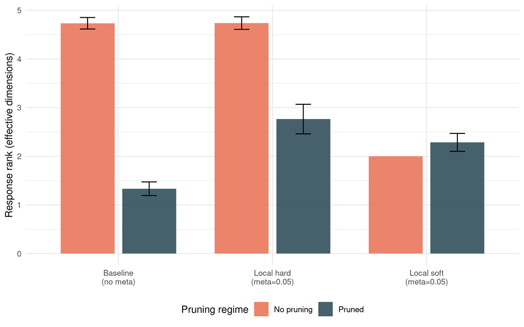

| Threshold | Hard (no-prune) | Tanh (no-prune) | Oja (no-prune) |
| --- | --- | --- | --- |
| $0.1\%$ | $5.9$ | $5.8$ | $6.4$ |
| $1\%$ (default) | $5.6$ | $5.5$ | $5.8$ |
| $5\%$ | $4.8$ | $4.8$ | $5.1$ |
| $10\%$ | $4.1$ | $4.2$ | $4.5$ |

The participation ratio—a threshold-free measure of effective dimensionality computed as $(\sum \sigma_i^2)^2 / \sum \sigma_i^4$ over the singular values $\sigma_i$—gives $2.2$ (hard), $2.1$ (tanh), and $2.2$ (oja) under Gaussian probes, rising to $3.2$, $3.1$, and $3.3$ under uniform (spatially deconfounded) probes.

The baseline condition (no metaplasticity) reaches the same rank as the metaplastic condition. Hard clipping alone produces functional diversity. Metaplasticity adds $\eta$ divergence (below) and increases assemblage count from $\sim 6$ to $10+$, but is not necessary for functional differentiation per se.

### 2.4 Eta differentiation requires absorbing boundaries

Per-assemblage learning rate ($\eta$) variance was measured under soft $\eta$ bounds ($n = 50$ seeds, 300 sessions). Of 50 seeds, 6 produced $\geq 2$ assemblages; the remaining 44 converged to monopoly (single assemblage). The failure mode is stochastic: monopoly and multi-assemblage seeds show identical $\eta$ statistics ($\bar{\eta} = 0.098$, $\sigma_\eta = 0.019$) and edge counts ($\sim 1{,}310$), and the qualifying seed count fluctuates between 5 and 8 across sessions with no trend, confirming that coexistence under hard weight + soft $\eta$ bounds is a rare but genuine dynamical regime.

For the 6 qualifying seeds:

| Statistic | Value |
| --- | --- |
| Mean $F$-ratio (between/within) | $4.91$ (SD $= 0.70$) |
| Bootstrap 95% CI (BCa, 10K) | $[4.40, 5.42]$ |
| $t(5) = 13.77$, $p$ (one-tailed) | $0.000018$ |
| Cohen’s $d$ | $5.62$ |

The $F$-ratio represents the ratio of between-assemblage $\eta$ variance to within-assemblage $\eta$ variance, computed separately within each seed and then aggregated via one-sample $t$-test against $F = 1$ across seeds. This avoids pseudoreplication from pooling assemblages across seeds. All soft weight bound conditions show $F < 1$ (tanh: $0.86$; oja: $0.76$). The absorbing weight boundary creates the structural asymmetry that the metaplastic instability requires.

### 2.5 CCD is spatially confounded

Centroid cosine distance was tested against a spatial null: weight values were randomly permuted across edges (preserving the edge topology but randomising which edges carry which weights), assemblages were re-detected on the permuted weights using the same adaptive threshold (75th percentile), and CCD was recomputed. This was repeated 1,000 times per seed ($n = 20$ seeds per condition). No condition reached $p < 0.05$.

A deconfounded response protocol (Exp R2) revealed that Gaussian probes inflated JS divergence by $0.27$ (spatial overlap between probe position and assemblage location) while deflating response rank from $3.1$–$3.3$ (uniform probes) to $2.0$–$2.2$ (Gaussian). The spatial structure of Gaussian probes created correlated activation across assemblages, collapsing independent functional dimensions.

## 3 Three Regimes of Individuation

[output not shown]

**Structural individuation**: the absorbing weight boundary creates saturated edges that resist competitive displacement, producing a rigid scaffold. Detection is threshold-robust. Functional diversity (rank $5.6$) emerges without metaplasticity.

**Metaplastic individuation**: local homeostasis drives $\eta$ divergence between assemblages ($F = 4.9$), increasing assemblage count and adding parametric differentiation—different learning dynamics across assemblages, not just different weight structures. Requires both the hard clip boundary and a local homeostatic mechanism.

These are nested: each regime subsumes the previous. Structural individuation requires the hard clip. Metaplastic individuation requires both the hard clip and local homeostasis.

## 4 Discussion

### 4.1 Pruning as unintended mould

The pruning threshold functions as a second absorbing boundary—one that was never theorised as part of the experimental mechanism. For hard-bounded edges (equilibrium $|w| \approx 1.0$), pruning at $10^{-4}$ removes only dead connections. For soft-bounded edges (equilibrium $|w| \approx 10^{-5.5}$), pruning destroys the substrate before individuation can occur. In Simondon’s (2020) terminology, pruning is an unintended *mould*: an external constraint that imposes form by eliminating structures that fall below its threshold, regardless of their functional contribution.

The disordinal interaction is direct evidence that the system’s individuating capacity depends on boundary conditions in a way that cannot be predicted from either boundary alone. The pruning confound has implications beyond this programme: any computational model that removes weak connections may be destroying exactly the exploratory structure that enables functional diversity. This parallels concerns in the synaptic pruning literature, where pruning is typically modeled as constructive (improving generalization by removing noise) rather than destructive (Chechik, Meilijson, and Ruppin 1998). Scholl, Rule, and Hennig (2021) showed formally that information-theoretic pruning criteria reduce generative diversity in deep Boltzmann machines, even when improving efficiency on surviving representations. Our work extends this in two directions: we characterise the *geometric* mechanism (response rank collapse, participation ratio reduction[^1]), and we demonstrate that the interaction is *disordinal* — not merely that pruning hurts some conditions more than others, but that it reverses the ranking of approaches entirely. The vulnerability of weakly-represented structure to pruning echoes a broader pattern: Granovetter (1973) showed that weak ties carry disproportionate novel information in social networks; analogously, low-magnitude connections in self-organising networks encode precisely the exploratory structure that enables functional diversity. In the neural network compression literature, Frankle and Carlin (2019) showed that dense networks contain sparse “winning ticket” subnetworks that match full-network performance; our weak inter-assemblage connections are the complementary phenomenon — “losing tickets” that carry no individual predictive value but whose collective presence scaffolds representational diversity. In biological development, silent synapses — connections that carry no current but serve structural roles during critical periods — provide a direct analog: they appear inactive by electrophysiological measures but are essential for circuit maturation.

### 4.2 The hard clip as limit condition

The non-monotonic steepness result demonstrates that the hard clip is not the infinite-steepness limit of soft saturation. It is qualitatively different: a *limit condition* in Simondon’s (2020) sense. A limit condition constrains the space of possible individuations without imposing specific form—it tells the system where it cannot go, not what it must become. The hard clip at $\pm w_\text{max}$ creates an absorbing state that edges can reach but not leave, producing a bimodal weight distribution that functions as a structural scaffold for functional diversity.

This is distinct from a *mould* (which imposes external form, as pruning does). The hard clip does not propagate from a local singularity as a seed crystal would—it constrains uniformly. But by constraining, it creates the asymmetric conditions under which the metaplastic dynamics can generate between-assemblage $\eta$ divergence.

### 4.3 Programme implications

The core narrative of the Dark Forest programme holds, but the mechanism is clarified. Papers 1–3 established individuation, coexistence, and self-sealing under hard bounds. Paper 4 demonstrated metaplastic differentiation. This paper reveals that pruning distorted the quantitative comparisons, that CCD was spatially confounded, and that functional differentiation is substantially stronger than originally reported (response rank $5.6$ vs $2.4$). The revised claim: local homeostatic metaplasticity stabilises and amplifies functional differentiation that Hebbian dynamics on spatially structured substrates spontaneously produce, provided the maintenance regime does not destroy the evidence.

## 5 Methods

### 5.1 Weight bounding strategies

Four strategies were compared: hard clip ($w = \text{clip}(w, -w_\text{max}, w_\text{max})$), tanh saturation ($w = w_\text{max} \tanh(w/w_\text{max})$), sigmoid saturation, and Oja normalisation. Sigmoid $\equiv$ tanh across all experiments to $\geq 4$ decimal places and is omitted from analysis.

### 5.2 Pruning conditions

Standard pruning: edges with $|w| < 10^{-4}$ removed each step. No-pruning: threshold $10^{-8}$ (effectively disabled). To prevent unbounded edge accumulation, a rank-based cap removes the weakest edges when total count exceeds a limit (default 20,000). A sensitivity analysis (caps at 5,000; 10,000; 20,000; 50,000; unlimited) confirms the cap never activates: edge count self-stabilises at $\sim 1{,}350$ on the $20 \times 20$ grid.

### 5.3 Response rank

After 200 training sessions, $K = 10$ structured input patterns (Gaussian bumps at random grid positions) are injected without further learning. Each assemblage’s mean response is recorded, producing a $K \times A$ response matrix. Effective rank: number of singular values exceeding a threshold percentage of the largest. We report rank at five thresholds ($0.1\%$, $0.5\%$, $1\%$, $5\%$, $10\%$) and the participation ratio $(\sum \sigma_i^2)^2 / \sum \sigma_i^4$ as a threshold-free alternative. Deconfounded probes use spatially uniform random stimuli $U[-0.3, 0.3]$ per node.

### 5.4 CCD null model

For each seed, weight values are randomly permuted across edges (preserving edge topology but randomising weight assignment). Assemblages are re-detected on the permuted weights using the same adaptive threshold (75th percentile of absolute weight). CCD is recomputed. This is repeated 1,000 times. The $p$-value is the proportion of null CCD values $\geq$ the observed CCD.

### 5.5 Statistical methods

Effect sizes: Cohen’s $d$ with bootstrap CIs (10,000 BCa). $\eta$ variance: per-seed $F$-ratios (between-assemblage / within-assemblage variance) aggregated via one-sample $t$-test against $F = 1$ across seeds, avoiding pseudoreplication from pooling assemblages across independent simulations. The 44/50 seeds converging to monopoly are reported as a failure-mode analysis rather than excluded silently.

## 6 References

Chechik, Gal, Isaac Meilijson, and Eytan Ruppin. 1998. “Synaptic Pruning in Development: A Computational Account.” *Neural Computation* 10 (7): 1759–77.

Frankle, Jonathan, and Michael Carlin. 2019. “The Lottery Ticket Hypothesis: Finding Sparse, Trainable Neural Networks.” In *International Conference on Learning Representations*.

Granovetter, Mark S. 1973. “The Strength of Weak Ties.” *American Journal of Sociology* 78 (6): 1360–80.

Holste, Gregory, Ziyu Jiang, Ajinkya Jia, Vishwesh Nath, Yuankai Huo, Bhavik N. Patel, and Song Wang. 2023. “How Does Pruning Impact Long-Tailed Multi-Label Medical Image Classifiers?” In *Medical Image Computing and Computer Assisted Intervention*. Springer.

Hooker, Sara, Aaron Courville, Gregory Clark, Yann Dauphin, and Andrea Frome. 2019. “What Do Compressed Deep Neural Networks Forget?” *arXiv Preprint arXiv:1911.05248*.

Lin, Xiaofeng, Seungbae Zhang, et al. 2022. “FairGRAPE: Fairness-Aware GRAdient Pruning mEthod for Face Attribute Classification.” In *European Conference on Computer Vision*. Springer.

Scholl, Carolin, Michael E. Rule, and Matthias H. Hennig. 2021. “The Information Theory of Developmental Pruning: Optimizing Global Network Architectures Using Local Synaptic Rules.” *PLoS Computational Biology* 17 (10): e1009458.

Simondon, Gilbert. 2020. *Individuation in Light of Notions of Form and Information*. Minneapolis: University of Minnesota Press.

Stringer, Carsen, Marius Pachitariu, Nicholas Steinmetz, Matteo Carandini, and Kenneth D. Harris. 2019. “High-Dimensional Geometry of Population Responses in Visual Cortex.” *Nature* 571: 361–65.

Tran, Cuong, Ferdinando Fioretto, Jung-Eun Kim, and Rakshit Naidu. 2022. “Pruning Has a Disparate Impact on Model Accuracy.” In *Advances in Neural Information Processing Systems*. Vol. 35.

## Footnotes

[^1]: This parallels the $1/n$ eigenspectrum observed in biological visual cortex by Stringer et al. (2019) — healthy representational spaces maintain a specific spectral profile that pruning disrupts.